# IE 6600_SEC 01_Group 23_Hackathon

2023-02-12

# 1.Introduction and Problem Statement

### The cultural, social, and political environment of a country are significantly influenced by religion. The general public is not well informed on how religious affiliations are distributed among nations, nevertheless. A thorough and user-friendly data visualization project is required to enable people to comprehend the religion demographics of various countries. The objective of this project is to produce interactive data visualizations that reveal information on the worldwide religious distribution. This initiative aims to promote public understanding and awareness of the complex and diverse religious landscape of countries around the world by presenting a clear and interesting portrayal of religious data from 1945 to 2010.

# 2.About the Dataset

### As per the resources shared, we decided to go ahead with World Religion Data from the Correlates of the War Project.It contains data about the number of adherents by religion in each of the states in the international system. These numbers are given for every half-decade period (1945, 1950,…, 2010). The WRP contains three datasets: the national religion dataset, the regional religion dataset, and the global religion dataset.

### Source of the data :- https://correlatesofwar.org/data-sets/world-religion-data/

# Section 1

## Question 1

### Analyze the proportion of global population which follow any sort of religious practices.

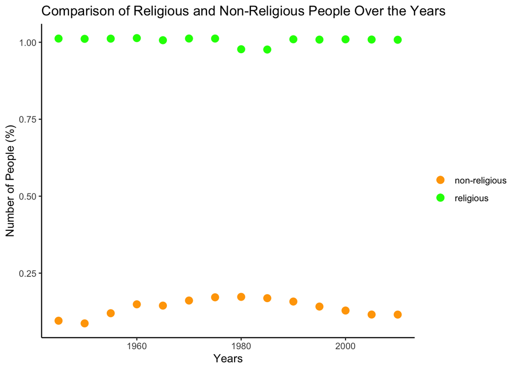

## Output 1

### From the graph plotted above,it is evident that a larger proportion of world’s population adhere to some sort of religious practices, hence the focus of analysis in the subsequent parts are the ones who adhere to any of religions.

## Question 2

### What is the change in the distribution of population of each religion globally from 1945 to 2010?

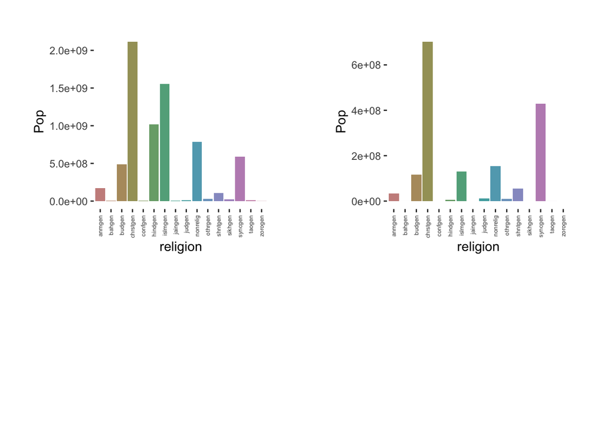

## Question 3

### Observe the variation in population of Christians and Islam from 1945 to 2010.

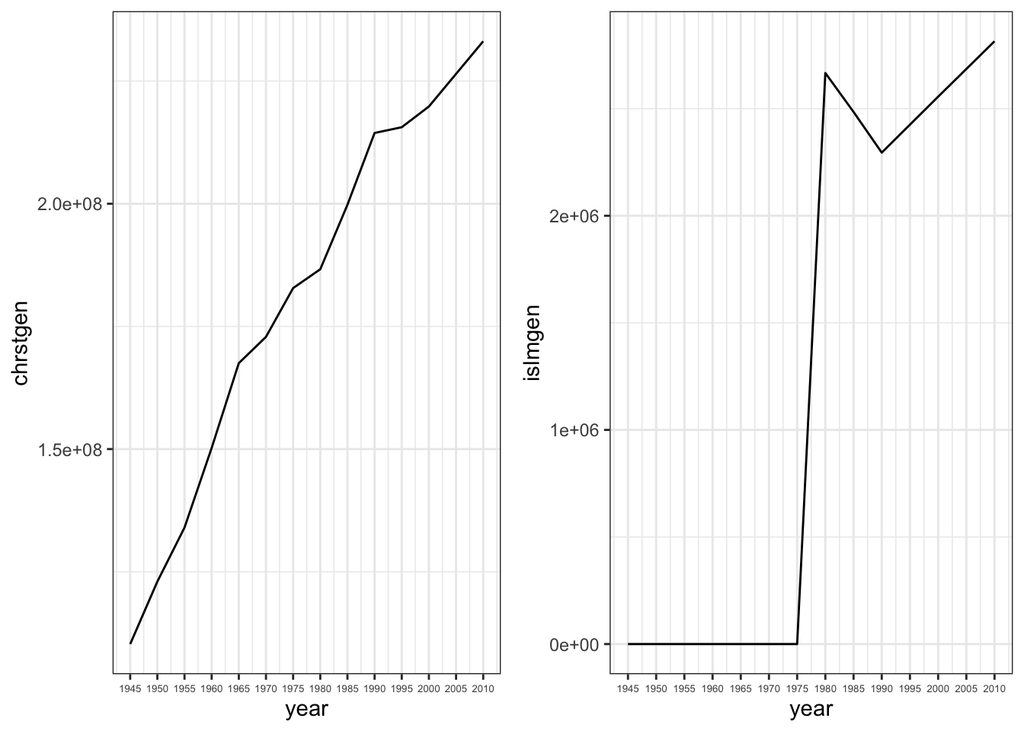

## Output 3

# Section 2

### Using the Regional Religion Dataset, we can identify regional trends in religious affiliation, such as regions with high growth or decline in a particular religion. The regions involved are Africa, Asia, Europe, Middle East and West Hemisphere. By comparing the data from the Regional Religion Dataset, we can compare the prevalence of different religions across regions and determine if there are patterns or differences. Since Christianity and Islam are the most prominent religions, the forthcoming analysis would be concentrated around these 2 religions.

## Question 1

### Identify the distributions of Christianity and Islam across all regions for the year 2010.

[figure not shown]

```
##       region    chrstgen     islmgen
## 66    Africa 460,005,841 246,404,472
## 67      Asia 287,921,863 804,756,836
## 68    Europe 557,677,984  51,222,711
## 69   Mideast  19,813,797 448,620,067
## 70 West. Hem 786,493,468   4,478,680
```

[figure not shown]

## Output 1

### From the 2 plots above,the piecharts and barcharts represent distribution of Christianity and Islam across all regions for the year 2010. For Christianity, Western Hemisphere has the most followers whereas for Islam, Asia leads the list.

## Question 2

### Analyze the composition of Christianity in Western Hemisphere and Islam in Asia.

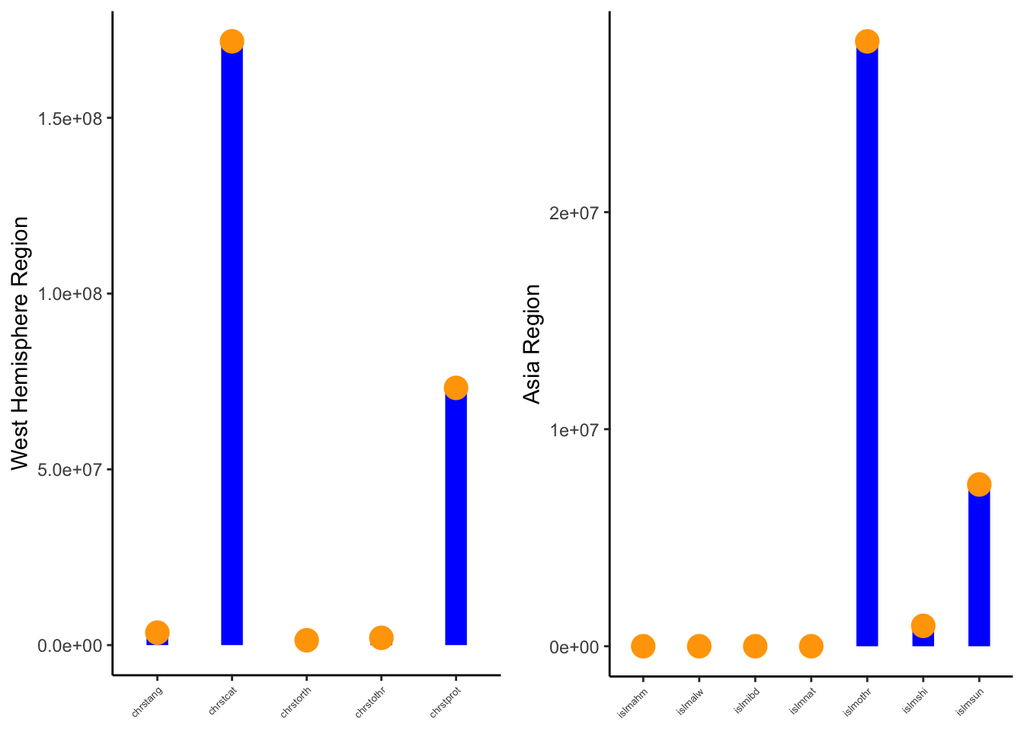

## Output 2

### The lollipop charts above present the composition of subreligions for Christianity and Islam in Western Hemisphere and Asia respectively.Roman Catholics comprise a major portion of Christians in West Hemisphere whereas the Others in Islam were in majority.

# Section 3

### Using the National Religion Dataset, we can visualize the different religious affiliations of each country and identify states with higher diversity or countries where one religion dominates the population. As per the previous sections, we analyzed the prominent religions over particular region. The consequent visualizations would be morspecific to countries.

## Question 1

### Analyze the spread of population of all religions in different countries and identify the countries where most number of Christians and Islam stay respectively.

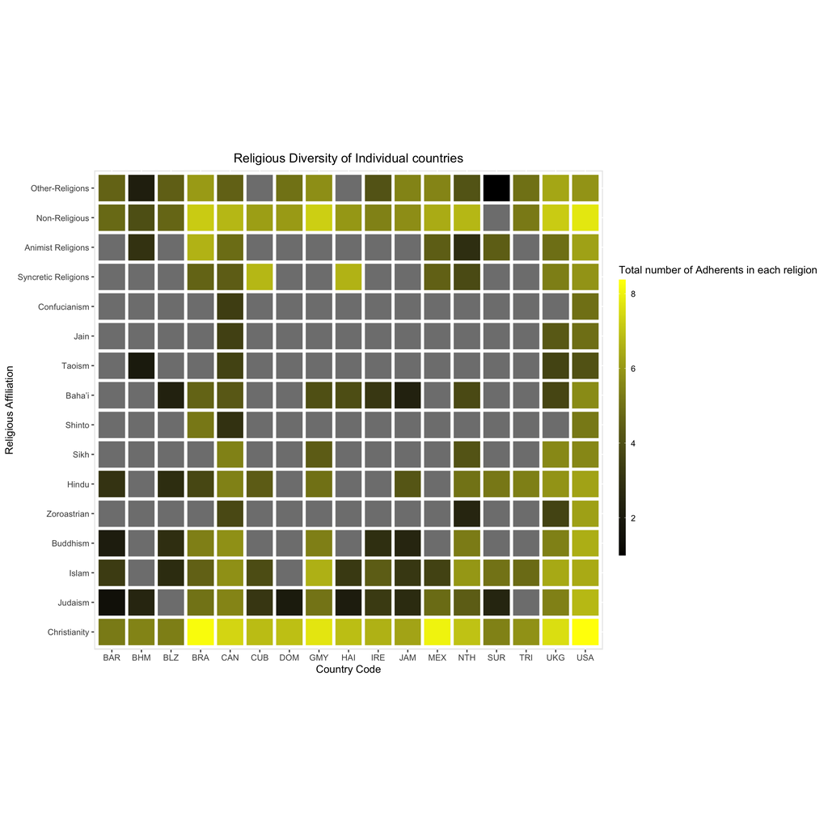

## Output 1

### The heatmap above depicts that USA is the country with highest number of Christians whereas GMY includes most number of Muslims. Hence the upcoming analysis would be based on the spread of various subreligions of Christians and Islam in USA and GMY respectively.

## Question 2

### Analyze the composition of sub categories of Christianity in USA as well as Islam in GMY.

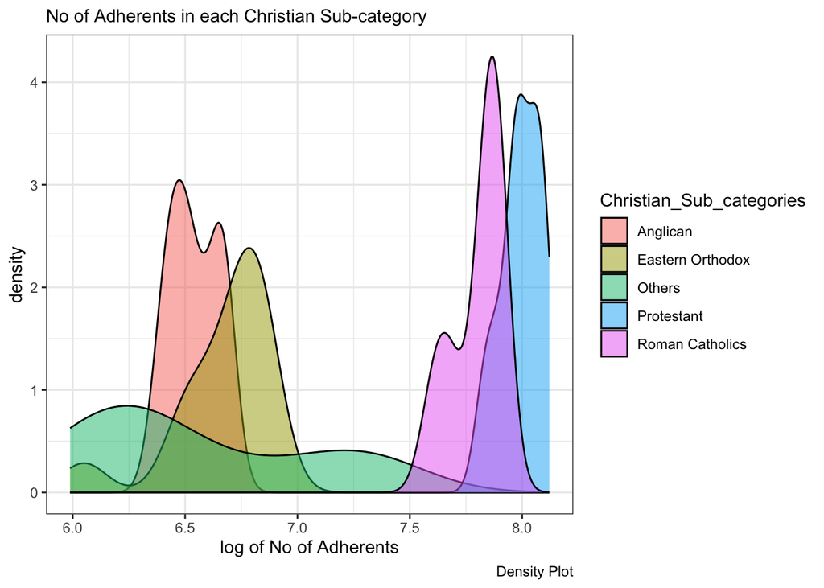

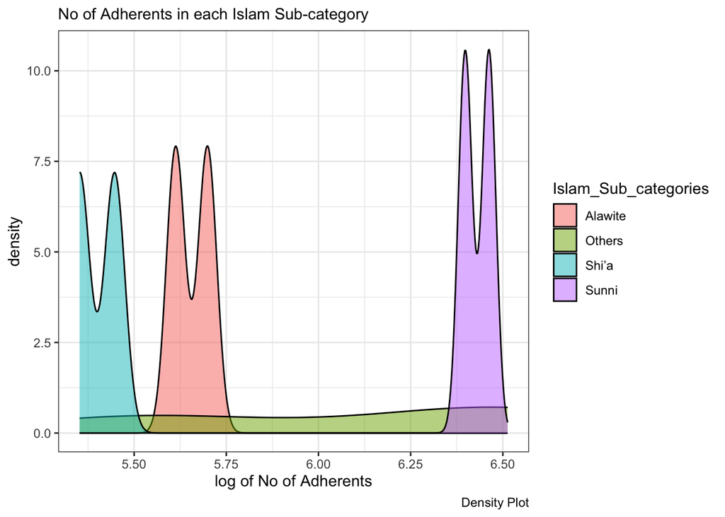

## Output 2

### The density plot shows the spread of various subreligions in Christianity and Islam in USA and GMY respectively.

# Summary and Conclusion